# Twitter Sentiment Analysis

Dhrubasattwata Roy Choudhury

## R Markdown

Using publicly available R packages that interact with major platforms such as RFacebook (Facebook), rtweet (Twitter) and Rblpapi (Bloomberg), RStudio’s visual interface and plotting tools have eased the way for sentiment analysis.

### Import the required packages

```r
library("rtweet")
library("dplyr")
library("tidyr")
library("tidyverse")
library("httpuv")
library("tidytext")
library("textdata")
```

### You need a twitter developer account

Visit https://cran.r-project.org/web/packages/rtweet/vignettes/auth.html for details.

### Store api keys (this will not be displayed for obvious reasons)

Create the five variables: app_name, api_key, api_secret_key,access_token, access_token_secret

### Authenticate via web browser

```r
token <- create_token(
  app = app_name,
  consumer_key = api_key,
  consumer_secret = api_secret_key,
  access_token = access_token,
  access_secret = access_token_secret)

get_token()
```

```
## <Token>
## <oauth_endpoint>
##  request:   https://api.twitter.com/oauth/request_token
##  authorize: https://api.twitter.com/oauth/authenticate
##  access:    https://api.twitter.com/oauth/access_token
## <oauth_app> RSentimentAnalysis_dsrc
##   key:    tUcVGVKyxp8SSZKJBIyJdtgmO
##   secret: <hidden>
## <credentials> oauth_token, oauth_token_secret
## ---
```

### Accessing Tweets

Only accessing English Tweets, because my language skills is limited.

```r
tweets1 <- search_tweets("#HagiaSophia", n=10000,include_rts = FALSE, lang="en")
tweets2 <- search_tweets("#Hagia_Sophia", n=10000,include_rts = FALSE, lang="en")
tweets3 <- search_tweets("#AyaSophia", n=10000,include_rts = FALSE, lang="en")
tweets4 <- search_tweets("#Aya_Sophia", n=10000,include_rts = FALSE, lang="en")
tweets <- rbind(tweets1, tweets2, tweets3, tweets4)
```

### Processing the Data

```r
# Keeping only the name and tweet
tweets.all<- tweets %>% select(screen_name,text)

## Clean up tweets
tweets.all$stripped_text1 <- gsub("http\\S+","",tweets.all$text)

# Use the unnest_tokens() function to convert to lowercase, remove punctuation and add ID
tweets.all_stem <- tweets.all %>% select(stripped_text1) %>% tidytext::unnest_tokens(word,stripped_text1)

# Remove Stop Words
cleaned_tweets.all <- tweets.all_stem %>% anti_join(stop_words)
## Let us also remove words like hagiasophia, ayasophia, sophia, hagia_sophia because this will not add any value to the analysis
x <- c("hagiasophia", "ayasophia", "sophia", "hagia_sophia", "ayasofya", "hagiasofia")
remove_words <- stop_words[1:6,]
remove_words[,1] <- x

cleaned_tweets.all <- cleaned_tweets.all %>% anti_join(remove_words)
```

### Some Basic Analysis

Find the top 20 commonly used words in the set of tweets; this will give an overall picture of what the populations are most concerned about, and the extent to which they are engaged on these topics.

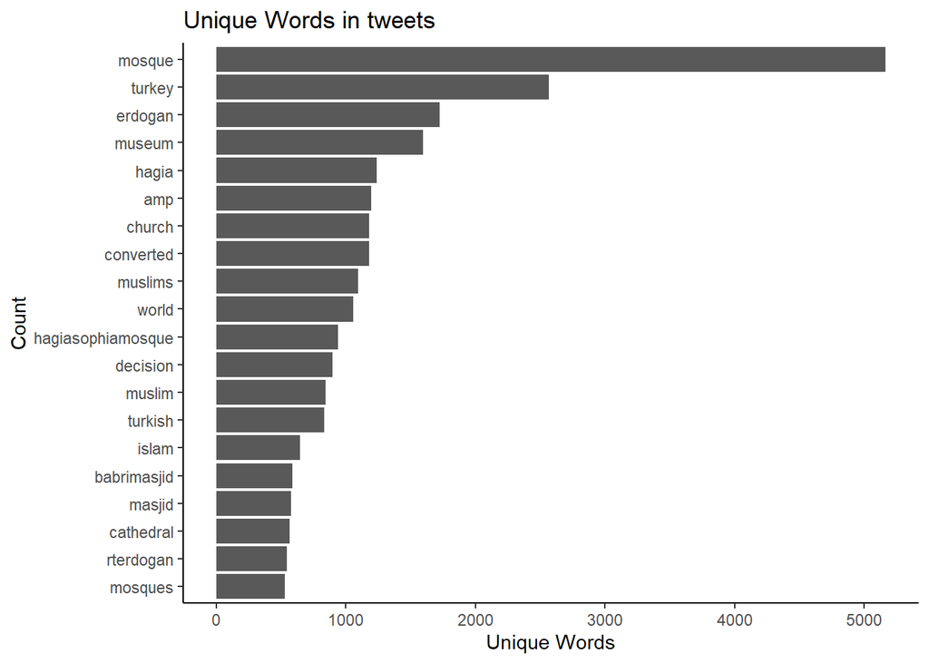

```r
cleaned_tweets.all %>%
  count(word,sort=TRUE) %>%
  top_n(20) %>%
  mutate(word = reorder(word,n)) %>%
  ggplot(aes(x=word,y=n)) + geom_col() + coord_flip() +theme_classic() +
  labs(x="Count",y="Unique Words", title= "Unique Words in tweets")
```

### Sentiment Analysis

Perform sentiment analysis using the Bing lexicon and get_sentiments function from the tidytext package. There are many libraries, dictionaries and packages available in R to evaluate the emotion prevalent in a text. The tidytext and textdata packages have such word-to-emotion evaluation repositories. Three of the general purpose lexicons are Bing, AFINN and nrc (from the textdata package).

```r
## Getting Sentiments
tidytext::get_sentiments("bing") %>% filter(sentiment=="positive")
```

```
## # A tibble: 2,005 x 2
##    word        sentiment
##    <chr>       <chr>
##  1 abound      positive
##  2 abounds     positive
##  3 abundance   positive
##  4 abundant    positive
##  5 accessable  positive
##  6 accessible  positive
##  7 acclaim     positive
##  8 acclaimed   positive
##  9 acclamation positive
## 10 accolade    positive
## # ... with 1,995 more rows
```

```r
tidytext::get_sentiments("bing") %>% filter(sentiment=="negative")
```

```
## # A tibble: 4,781 x 2
##    word        sentiment
##    <chr>       <chr>
##  1 2-faces     negative
##  2 abnormal    negative
##  3 abolish     negative
##  4 abominable  negative
##  5 abominably  negative
##  6 abominate   negative
##  7 abomination negative
##  8 abort       negative
##  9 aborted     negative
## 10 aborts      negative
## # ... with 4,771 more rows
```

In contrast to Bing, the AFINN lexicon assigns a “positive” or “negative” score to each word in its lexicon; further sentiment analysis will then add up the emotion score to determine overall expression. A score greater than zero indicates positive sentiment, while a score less than zero would mean negative overall emotion. A calculated score of zero indicates neutral sentiment (neither positive or negative). We will do our analysis using Bing sentiments.

```r
bing_all <- cleaned_tweets.all %>%
  inner_join(get_sentiments("bing")) %>%
  count(word,sentiment,sort=TRUE) %>%
  ungroup()
```

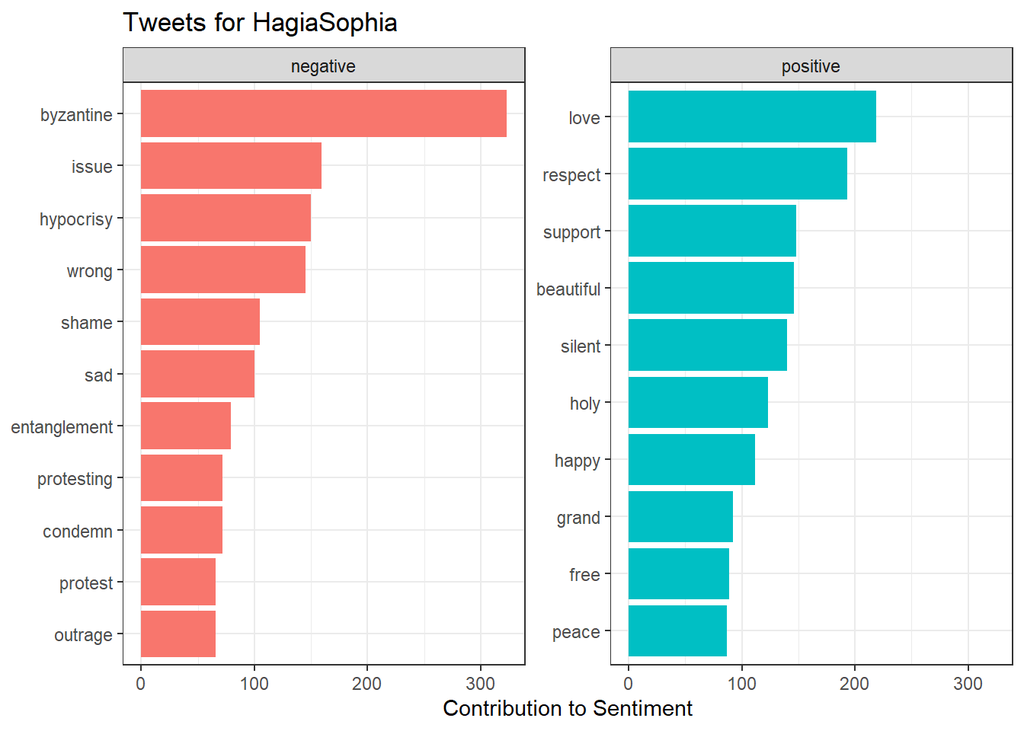

```r
bing_all %>%
  group_by(sentiment) %>%
  top_n(10) %>%
  ungroup() %>%
  mutate(word = reorder(word,n)) %>%
  ggplot(aes(word,n,fill=sentiment)) +
  geom_col(show.legend = FALSE) +
  facet_wrap(~sentiment,scales="free_y")+
  labs(title="Tweets for HagiaSophia",y="Contribution to Sentiment",x=NULL)+
  coord_flip() + theme_bw()
```

### Sentiment Score for each tweet

```r
sentiment_bing <- function(twt){
  #Step 1: perform basic cleaning of tweet
  twt_tbl <- tibble(text=twt) %>%
    mutate(stripped_text = gsub("http\\S+","",text)) %>%
    unnest_tokens(word,stripped_text) %>%
    anti_join(stop_words) %>% #remove stop_words
    inner_join(get_sentiments("bing")) %>% #merge with bing sentiments
    count(word,sentiment,sort=TRUE)%>%
    ungroup() %>%
    mutate( # Calculate Score : 1 for positive word, -1 for negatives
      score= case_when(
        sentiment == "negative" ~ n*(-1),
        sentiment == "postive" ~ n*1
      )
    ) #Calculate Total Score
  sent.score= case_when(
    nrow(twt_tbl) == 0~0,
    nrow(twt_tbl) >0~sum(twt_tbl$score)
  )
  zero.type = case_when(
    nrow(twt_tbl) == 0~"Type 1", #no words
    nrow(twt_tbl) >0~"Type 2" #sum of words is 0
  )
  list(score=sent.score,type=zero.type,twt_tbl=twt_tbl)
}

all_sentiment <- lapply(tweets$text,function(x){sentiment_bing(x)})
# all_sentiment
```

### Plotting the histogram of scores

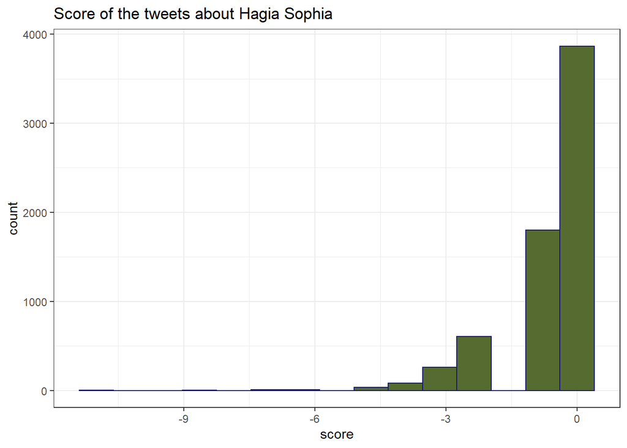

```r
## Plotting Histogram

sentiment <- bind_rows(
  tibble(
    about = "#Hagia Sophia",
    score = unlist(map(all_sentiment,'score')),
    type = unlist(map(all_sentiment,'type'))
  )
)

ggplot(sentiment, aes(x=score)) + geom_histogram(bins=15, alpha = 1, color = "midnightblue", fill = "darkolivegreen") + ggtitle("Score of the tweets about Hagia Sophia") +  theme_bw()
```